# W3cubDocs

/GTK 4.0

# GtkTextView

GtkTextView — Widget that displays a GtkTextBuffer

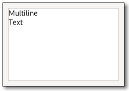

## Functions

| GtkWidget * | gtk_text_view_new () |
| --- | --- |
| GtkWidget * | gtk_text_view_new_with_buffer () |
| void | gtk_text_view_set_buffer () |
| GtkTextBuffer * | gtk_text_view_get_buffer () |
| void | gtk_text_view_scroll_to_mark () |
| gboolean | gtk_text_view_scroll_to_iter () |
| void | gtk_text_view_scroll_mark_onscreen () |
| gboolean | gtk_text_view_move_mark_onscreen () |
| gboolean | gtk_text_view_place_cursor_onscreen () |
| void | gtk_text_view_get_visible_rect () |
| void | gtk_text_view_get_iter_location () |
| void | gtk_text_view_get_cursor_locations () |
| void | gtk_text_view_get_line_at_y () |
| void | gtk_text_view_get_line_yrange () |
| gboolean | gtk_text_view_get_iter_at_location () |
| gboolean | gtk_text_view_get_iter_at_position () |
| void | gtk_text_view_buffer_to_window_coords () |
| void | gtk_text_view_window_to_buffer_coords () |
| gboolean | gtk_text_view_forward_display_line () |
| gboolean | gtk_text_view_backward_display_line () |
| gboolean | gtk_text_view_forward_display_line_end () |
| gboolean | gtk_text_view_backward_display_line_start () |
| gboolean | gtk_text_view_starts_display_line () |
| gboolean | gtk_text_view_move_visually () |
| void | gtk_text_view_add_child_at_anchor () |
| void | gtk_text_view_remove () |
| GtkTextChildAnchor * | gtk_text_child_anchor_new () |
| GtkWidget ** | gtk_text_child_anchor_get_widgets () |
| gboolean | gtk_text_child_anchor_get_deleted () |
| GtkWidget * | gtk_text_view_get_gutter () |
| void | gtk_text_view_set_gutter () |
| void | gtk_text_view_add_overlay () |
| void | gtk_text_view_move_overlay () |
| void | gtk_text_view_set_wrap_mode () |
| GtkWrapMode | gtk_text_view_get_wrap_mode () |
| void | gtk_text_view_set_editable () |
| gboolean | gtk_text_view_get_editable () |
| void | gtk_text_view_set_cursor_visible () |
| gboolean | gtk_text_view_get_cursor_visible () |
| void | gtk_text_view_reset_cursor_blink () |
| void | gtk_text_view_set_overwrite () |
| gboolean | gtk_text_view_get_overwrite () |
| void | gtk_text_view_set_pixels_above_lines () |
| int | gtk_text_view_get_pixels_above_lines () |
| void | gtk_text_view_set_pixels_below_lines () |
| int | gtk_text_view_get_pixels_below_lines () |
| void | gtk_text_view_set_pixels_inside_wrap () |
| int | gtk_text_view_get_pixels_inside_wrap () |
| void | gtk_text_view_set_justification () |
| GtkJustification | gtk_text_view_get_justification () |
| void | gtk_text_view_set_left_margin () |
| int | gtk_text_view_get_left_margin () |
| void | gtk_text_view_set_right_margin () |
| int | gtk_text_view_get_right_margin () |
| void | gtk_text_view_set_top_margin () |
| int | gtk_text_view_get_top_margin () |
| void | gtk_text_view_set_bottom_margin () |
| int | gtk_text_view_get_bottom_margin () |
| void | gtk_text_view_set_indent () |
| int | gtk_text_view_get_indent () |
| void | gtk_text_view_set_tabs () |
| [PangoTabArray](https://developer.gnome.org/pango/stable/pango-Tab-Stops.html#PangoTabArray-struct) * | gtk_text_view_get_tabs () |
| void | gtk_text_view_set_accepts_tab () |
| gboolean | gtk_text_view_get_accepts_tab () |
| gboolean | gtk_text_view_im_context_filter_keypress () |
| void | gtk_text_view_reset_im_context () |
| void | gtk_text_view_set_input_purpose () |
| GtkInputPurpose | gtk_text_view_get_input_purpose () |
| void | gtk_text_view_set_input_hints () |
| GtkInputHints | gtk_text_view_get_input_hints () |
| void | gtk_text_view_set_monospace () |
| gboolean | gtk_text_view_get_monospace () |
| void | gtk_text_view_set_extra_menu () |
| GMenuModel * | gtk_text_view_get_extra_menu () |

## Properties

| gboolean | accepts-tab | Read / Write |
| --- | --- | --- |
| int | bottom-margin | Read / Write |
| GtkTextBuffer * | buffer | Read / Write |
| gboolean | cursor-visible | Read / Write |
| gboolean | editable | Read / Write |
| GMenuModel * | extra-menu | Read / Write |
| char * | im-module | Read / Write |
| int | indent | Read / Write |
| GtkInputHints | input-hints | Read / Write |
| GtkInputPurpose | input-purpose | Read / Write |
| GtkJustification | justification | Read / Write |
| int | left-margin | Read / Write |
| gboolean | monospace | Read / Write |
| gboolean | overwrite | Read / Write |
| int | pixels-above-lines | Read / Write |
| int | pixels-below-lines | Read / Write |
| int | pixels-inside-wrap | Read / Write |
| int | right-margin | Read / Write |
| [PangoTabArray](https://developer.gnome.org/pango/stable/pango-Tab-Stops.html#PangoTabArray-struct) * | tabs | Read / Write |
| int | top-margin | Read / Write |
| GtkWrapMode | wrap-mode | Read / Write |

## Signals

| void | backspace | Action |
| --- | --- | --- |
| void | copy-clipboard | Action |
| void | cut-clipboard | Action |
| void | delete-from-cursor | Action |
| gboolean | extend-selection | Run Last |
| void | insert-at-cursor | Action |
| void | insert-emoji | Action |
| void | move-cursor | Action |
| void | move-viewport | Action |
| void | paste-clipboard | Action |
| void | preedit-changed | Action |
| void | select-all | Action |
| void | set-anchor | Action |
| void | toggle-cursor-visible | Action |
| void | toggle-overwrite | Action |

## Actions

|  | menu.popup |  |
| --- | --- | --- |
|  | text.redo |  |
|  | text.undo |  |
|  | misc.insert-emoji |  |
|  | selection.select-all |  |
|  | selection.delete |  |
|  | clipboard.paste |  |
|  | clipboard.copy |  |
|  | clipboard.cut |  |

## Types and Values

| struct | GtkTextView |
| --- | --- |
| struct | GtkTextViewClass |
| enum | GtkTextViewLayer |
| enum | GtkTextWindowType |
| enum | GtkTextExtendSelection |
| enum | GtkWrapMode |
| struct | GtkTextChildAnchor |
| #define | GTK_TEXT_VIEW_PRIORITY_VALIDATE |

## Object Hierarchy

```
    GObject
    ├── GInitiallyUnowned
    │   ╰── GtkWidget
    │       ╰── GtkTextView
    ╰── GtkTextChildAnchor
```

## Implemented Interfaces

GtkTextView implements GtkAccessible, GtkBuildable, GtkConstraintTarget and GtkScrollable.

## Includes

```
#include <gtk/gtk.h>
```

## Description

You may wish to begin by reading the text widget conceptual overview which gives an overview of all the objects and data types related to the text widget and how they work together.

### CSS nodes

GtkTextView has a main css node with name textview and style class .view, and subnodes for each of the border windows, and the main text area, with names border and text, respectively. The border nodes each get one of the style classes .left, .right, .top or .bottom.

A node representing the selection will appear below the text node.

If a context menu is opened, the window node will appear as a subnode of the main node.

### Accessibility

GtkTextView uses the GTK_ACCESSIBLE_ROLE_TEXT_BOX role.

## Functions

### gtk_text_view_new ()

```
GtkWidget *
gtk_text_view_new (void);
```

Creates a new GtkTextView. If you don’t call `gtk_text_view_set_buffer()` before using the text view, an empty default buffer will be created for you. Get the buffer with `gtk_text_view_get_buffer()`. If you want to specify your own buffer, consider `gtk_text_view_new_with_buffer()`.

#### Returns

a new GtkTextView

### gtk_text_view_new_with_buffer ()

```
GtkWidget *
gtk_text_view_new_with_buffer (GtkTextBuffer *buffer);
```

Creates a new GtkTextView widget displaying the buffer *`buffer`* . One buffer can be shared among many widgets. *`buffer`* may be `NULL` to create a default buffer, in which case this function is equivalent to `gtk_text_view_new()`. The text view adds its own reference count to the buffer; it does not take over an existing reference.

#### Parameters

| buffer | a GtkTextBuffer |  |
| --- | --- | --- |

#### Returns

a new GtkTextView.

### gtk_text_view_set_buffer ()

```
void
gtk_text_view_set_buffer (GtkTextView *text_view,
                          GtkTextBuffer *buffer);
```

Sets *`buffer`* as the buffer being displayed by *`text_view`* . The previous buffer displayed by the text view is unreferenced, and a reference is added to *`buffer`* . If you owned a reference to *`buffer`* before passing it to this function, you must remove that reference yourself; GtkTextView will not “adopt” it.

#### Parameters

| text_view | a GtkTextView |  |
| --- | --- | --- |
| buffer | a GtkTextBuffer. | [allow-none] |

### gtk_text_view_get_buffer ()

```
GtkTextBuffer *
gtk_text_view_get_buffer (GtkTextView *text_view);
```

Returns the GtkTextBuffer being displayed by this text view. The reference count on the buffer is not incremented; the caller of this function won’t own a new reference.

#### Parameters

| text_view | a GtkTextView |  |
| --- | --- | --- |

#### Returns

a GtkTextBuffer.

[transfer none]

### gtk_text_view_scroll_to_mark ()

```
void
gtk_text_view_scroll_to_mark (GtkTextView *text_view,
                              GtkTextMark *mark,
                              double within_margin,
                              gboolean use_align,
                              double xalign,
                              double yalign);
```

Scrolls *`text_view`* so that *`mark`* is on the screen in the position indicated by *`xalign`* and *`yalign`* . An alignment of 0.0 indicates left or top, 1.0 indicates right or bottom, 0.5 means center. If *`use_align`* is `FALSE`, the text scrolls the minimal distance to get the mark onscreen, possibly not scrolling at all. The effective screen for purposes of this function is reduced by a margin of size *`within_margin`* .

#### Parameters

| text_view | a GtkTextView |  |
| --- | --- | --- |
| mark | a GtkTextMark |  |
| within_margin | margin as a [0.0,0.5) fraction of screen size |  |
| use_align | whether to use alignment arguments (if `FALSE`, just get the mark onscreen) |  |
| xalign | horizontal alignment of mark within visible area |  |
| yalign | vertical alignment of mark within visible area |  |

### gtk_text_view_scroll_to_iter ()

```
gboolean
gtk_text_view_scroll_to_iter (GtkTextView *text_view,
                              GtkTextIter *iter,
                              double within_margin,
                              gboolean use_align,
                              double xalign,
                              double yalign);
```

Scrolls *`text_view`* so that *`iter`* is on the screen in the position indicated by *`xalign`* and *`yalign`* . An alignment of 0.0 indicates left or top, 1.0 indicates right or bottom, 0.5 means center. If *`use_align`* is `FALSE`, the text scrolls the minimal distance to get the mark onscreen, possibly not scrolling at all. The effective screen for purposes of this function is reduced by a margin of size *`within_margin`* .

Note that this function uses the currently-computed height of the lines in the text buffer. Line heights are computed in an idle handler; so this function may not have the desired effect if it’s called before the height computations. To avoid oddness, consider using `gtk_text_view_scroll_to_mark()` which saves a point to be scrolled to after line validation.

#### Parameters

| text_view | a GtkTextView |  |
| --- | --- | --- |
| iter | a GtkTextIter |  |
| within_margin | margin as a [0.0,0.5) fraction of screen size |  |
| use_align | whether to use alignment arguments (if `FALSE`, just get the mark onscreen) |  |
| xalign | horizontal alignment of mark within visible area |  |
| yalign | vertical alignment of mark within visible area |  |

#### Returns

`TRUE` if scrolling occurred

### gtk_text_view_scroll_mark_onscreen ()

```
void
gtk_text_view_scroll_mark_onscreen (GtkTextView *text_view,
                                    GtkTextMark *mark);
```

Scrolls *`text_view`* the minimum distance such that *`mark`* is contained within the visible area of the widget.

#### Parameters

| text_view | a GtkTextView |  |
| --- | --- | --- |
| mark | a mark in the buffer for *`text_view`* |  |

### gtk_text_view_move_mark_onscreen ()

```
gboolean
gtk_text_view_move_mark_onscreen (GtkTextView *text_view,
                                  GtkTextMark *mark);
```

Moves a mark within the buffer so that it's located within the currently-visible text area.

#### Parameters

| text_view | a GtkTextView |  |
| --- | --- | --- |
| mark | a GtkTextMark |  |

#### Returns

`TRUE` if the mark moved (wasn’t already onscreen)

### gtk_text_view_place_cursor_onscreen ()

```
gboolean
gtk_text_view_place_cursor_onscreen (GtkTextView *text_view);
```

Moves the cursor to the currently visible region of the buffer, if it isn’t there already.

#### Parameters

| text_view | a GtkTextView |  |
| --- | --- | --- |

#### Returns

`TRUE` if the cursor had to be moved.

### gtk_text_view_get_visible_rect ()

```
void
gtk_text_view_get_visible_rect (GtkTextView *text_view,
                                GdkRectangle *visible_rect);
```

Fills *`visible_rect`* with the currently-visible region of the buffer, in buffer coordinates. Convert to window coordinates with `gtk_text_view_buffer_to_window_coords()`.

#### Parameters

| text_view | a GtkTextView |  |
| --- | --- | --- |
| visible_rect | rectangle to fill. | [out] |

### gtk_text_view_get_iter_location ()

```
void
gtk_text_view_get_iter_location (GtkTextView *text_view,
                                 const GtkTextIter *iter,
                                 GdkRectangle *location);
```

Gets a rectangle which roughly contains the character at *`iter`* . The rectangle position is in buffer coordinates; use `gtk_text_view_buffer_to_window_coords()` to convert these coordinates to coordinates for one of the windows in the text view.

#### Parameters

| text_view | a GtkTextView |  |
| --- | --- | --- |
| iter | a GtkTextIter |  |
| location | bounds of the character at *`iter`* . | [out] |

### gtk_text_view_get_cursor_locations ()

```
void
gtk_text_view_get_cursor_locations (GtkTextView *text_view,
                                    const GtkTextIter *iter,
                                    GdkRectangle *strong,
                                    GdkRectangle *weak);
```

Given an *`iter`* within a text layout, determine the positions of the strong and weak cursors if the insertion point is at that iterator. The position of each cursor is stored as a zero-width rectangle. The strong cursor location is the location where characters of the directionality equal to the base direction of the paragraph are inserted. The weak cursor location is the location where characters of the directionality opposite to the base direction of the paragraph are inserted.

If *`iter`* is `NULL`, the actual cursor position is used.

Note that if *`iter`* happens to be the actual cursor position, and there is currently an IM preedit sequence being entered, the returned locations will be adjusted to account for the preedit cursor’s offset within the preedit sequence.

The rectangle position is in buffer coordinates; use `gtk_text_view_buffer_to_window_coords()` to convert these coordinates to coordinates for one of the windows in the text view.

#### Parameters

| text_view | a GtkTextView |  |
| --- | --- | --- |
| iter | a GtkTextIter. | [allow-none] |
| strong | location to store the strong cursor position (may be `NULL`). | [out][allow-none] |
| weak | location to store the weak cursor position (may be `NULL`). | [out][allow-none] |

### gtk_text_view_get_line_at_y ()

```
void
gtk_text_view_get_line_at_y (GtkTextView *text_view,
                             GtkTextIter *target_iter,
                             int y,
                             int *line_top);
```

Gets the GtkTextIter at the start of the line containing the coordinate *`y`* . *`y`* is in buffer coordinates, convert from window coordinates with `gtk_text_view_window_to_buffer_coords()`. If non-`NULL`, *`line_top`* will be filled with the coordinate of the top edge of the line.

#### Parameters

| text_view | a GtkTextView |  |
| --- | --- | --- |
| target_iter | a GtkTextIter. | [out] |
| y | a y coordinate |  |
| line_top | return location for top coordinate of the line. | [out] |

### gtk_text_view_get_line_yrange ()

```
void
gtk_text_view_get_line_yrange (GtkTextView *text_view,
                               const GtkTextIter *iter,
                               int *y,
                               int *height);
```

Gets the y coordinate of the top of the line containing *`iter`* , and the height of the line. The coordinate is a buffer coordinate; convert to window coordinates with `gtk_text_view_buffer_to_window_coords()`.

#### Parameters

| text_view | a GtkTextView |  |
| --- | --- | --- |
| iter | a GtkTextIter |  |
| y | return location for a y coordinate. | [out] |
| height | return location for a height. | [out] |

### gtk_text_view_get_iter_at_location ()

```
gboolean
gtk_text_view_get_iter_at_location (GtkTextView *text_view,
                                    GtkTextIter *iter,
                                    int x,
                                    int y);
```

Retrieves the iterator at buffer coordinates *`x`* and *`y`* . Buffer coordinates are coordinates for the entire buffer, not just the currently-displayed portion. If you have coordinates from an event, you have to convert those to buffer coordinates with `gtk_text_view_window_to_buffer_coords()`.

#### Parameters

| text_view | a GtkTextView |  |
| --- | --- | --- |
| iter | a GtkTextIter. | [out] |
| x | x position, in buffer coordinates |  |
| y | y position, in buffer coordinates |  |

#### Returns

`TRUE` if the position is over text

### gtk_text_view_get_iter_at_position ()

```
gboolean
gtk_text_view_get_iter_at_position (GtkTextView *text_view,
                                    GtkTextIter *iter,
                                    int *trailing,
                                    int x,
                                    int y);
```

Retrieves the iterator pointing to the character at buffer coordinates *`x`* and *`y`* . Buffer coordinates are coordinates for the entire buffer, not just the currently-displayed portion. If you have coordinates from an event, you have to convert those to buffer coordinates with `gtk_text_view_window_to_buffer_coords()`.

Note that this is different from `gtk_text_view_get_iter_at_location()`, which returns cursor locations, i.e. positions between characters.

#### Parameters

[output not shown]

#### Returns

`TRUE` if the position is over text

### gtk_text_view_buffer_to_window_coords ()

```
void
gtk_text_view_buffer_to_window_coords (GtkTextView *text_view,
                                       GtkTextWindowType win,
                                       int buffer_x,
                                       int buffer_y,
                                       int *window_x,
                                       int *window_y);
```

Converts coordinate (*`buffer_x`* , *`buffer_y`* ) to coordinates for the window *`win`* , and stores the result in (*`window_x`* , *`window_y`* ).

#### Parameters

| text_view | a GtkTextView |  |
| --- | --- | --- |
| win | a GtkTextWindowType |  |
| buffer_x | buffer x coordinate |  |
| buffer_y | buffer y coordinate |  |
| window_x | window x coordinate return location or `NULL`. | [out][allow-none] |
| window_y | window y coordinate return location or `NULL`. | [out][allow-none] |

### gtk_text_view_window_to_buffer_coords ()

```
void
gtk_text_view_window_to_buffer_coords (GtkTextView *text_view,
                                       GtkTextWindowType win,
                                       int window_x,
                                       int window_y,
                                       int *buffer_x,
                                       int *buffer_y);
```

Converts coordinates on the window identified by *`win`* to buffer coordinates, storing the result in (*`buffer_x`* ,*`buffer_y`* ).

#### Parameters

| text_view | a GtkTextView |  |
| --- | --- | --- |
| win | a GtkTextWindowType |  |
| window_x | window x coordinate |  |
| window_y | window y coordinate |  |
| buffer_x | buffer x coordinate return location or `NULL`. | [out][allow-none] |
| buffer_y | buffer y coordinate return location or `NULL`. | [out][allow-none] |

### gtk_text_view_forward_display_line ()

```
gboolean
gtk_text_view_forward_display_line (GtkTextView *text_view,
                                    GtkTextIter *iter);
```

Moves the given *`iter`* forward by one display (wrapped) line. A display line is different from a paragraph. Paragraphs are separated by newlines or other paragraph separator characters. Display lines are created by line-wrapping a paragraph. If wrapping is turned off, display lines and paragraphs will be the same. Display lines are divided differently for each view, since they depend on the view’s width; paragraphs are the same in all views, since they depend on the contents of the GtkTextBuffer.

#### Parameters

| text_view | a GtkTextView |  |
| --- | --- | --- |
| iter | a GtkTextIter |  |

#### Returns

`TRUE` if *`iter`* was moved and is not on the end iterator

### gtk_text_view_backward_display_line ()

```
gboolean
gtk_text_view_backward_display_line (GtkTextView *text_view,
                                     GtkTextIter *iter);
```

Moves the given *`iter`* backward by one display (wrapped) line. A display line is different from a paragraph. Paragraphs are separated by newlines or other paragraph separator characters. Display lines are created by line-wrapping a paragraph. If wrapping is turned off, display lines and paragraphs will be the same. Display lines are divided differently for each view, since they depend on the view’s width; paragraphs are the same in all views, since they depend on the contents of the GtkTextBuffer.

#### Parameters

| text_view | a GtkTextView |  |
| --- | --- | --- |
| iter | a GtkTextIter |  |

#### Returns

`TRUE` if *`iter`* was moved and is not on the end iterator

### gtk_text_view_forward_display_line_end ()

```
gboolean
gtk_text_view_forward_display_line_end
                               (GtkTextView *text_view,
                                GtkTextIter *iter);
```

Moves the given *`iter`* forward to the next display line end. A display line is different from a paragraph. Paragraphs are separated by newlines or other paragraph separator characters. Display lines are created by line-wrapping a paragraph. If wrapping is turned off, display lines and paragraphs will be the same. Display lines are divided differently for each view, since they depend on the view’s width; paragraphs are the same in all views, since they depend on the contents of the GtkTextBuffer.

#### Parameters

| text_view | a GtkTextView |  |
| --- | --- | --- |
| iter | a GtkTextIter |  |

#### Returns

`TRUE` if *`iter`* was moved and is not on the end iterator

### gtk_text_view_backward_display_line_start ()

```
gboolean
gtk_text_view_backward_display_line_start
                               (GtkTextView *text_view,
                                GtkTextIter *iter);
```

Moves the given *`iter`* backward to the next display line start. A display line is different from a paragraph. Paragraphs are separated by newlines or other paragraph separator characters. Display lines are created by line-wrapping a paragraph. If wrapping is turned off, display lines and paragraphs will be the same. Display lines are divided differently for each view, since they depend on the view’s width; paragraphs are the same in all views, since they depend on the contents of the GtkTextBuffer.

#### Parameters

| text_view | a GtkTextView |  |
| --- | --- | --- |
| iter | a GtkTextIter |  |

#### Returns

`TRUE` if *`iter`* was moved and is not on the end iterator

### gtk_text_view_starts_display_line ()

```
gboolean
gtk_text_view_starts_display_line (GtkTextView *text_view,
                                   const GtkTextIter *iter);
```

Determines whether *`iter`* is at the start of a display line. See `gtk_text_view_forward_display_line()` for an explanation of display lines vs. paragraphs.

#### Parameters

| text_view | a GtkTextView |  |
| --- | --- | --- |
| iter | a GtkTextIter |  |

#### Returns

`TRUE` if *`iter`* begins a wrapped line

### gtk_text_view_move_visually ()

```
gboolean
gtk_text_view_move_visually (GtkTextView *text_view,
                             GtkTextIter *iter,
                             int count);
```

Move the iterator a given number of characters visually, treating it as the strong cursor position. If *`count`* is positive, then the new strong cursor position will be *`count`* positions to the right of the old cursor position. If *`count`* is negative then the new strong cursor position will be *`count`* positions to the left of the old cursor position.

In the presence of bi-directional text, the correspondence between logical and visual order will depend on the direction of the current run, and there may be jumps when the cursor is moved off of the end of a run.

#### Parameters

| text_view | a GtkTextView |  |
| --- | --- | --- |
| iter | a GtkTextIter |  |
| count | number of characters to move (negative moves left, positive moves right) |  |

#### Returns

`TRUE` if *`iter`* moved and is not on the end iterator

### gtk_text_view_add_child_at_anchor ()

```
void
gtk_text_view_add_child_at_anchor (GtkTextView *text_view,
                                   GtkWidget *child,
                                   GtkTextChildAnchor *anchor);
```

Adds a child widget in the text buffer, at the given *`anchor`* .

#### Parameters

| text_view | a GtkTextView |  |
| --- | --- | --- |
| child | a GtkWidget |  |
| anchor | a GtkTextChildAnchor in the GtkTextBuffer for *`text_view`* |  |

### gtk_text_view_remove ()

```
void
gtk_text_view_remove (GtkTextView *text_view,
                      GtkWidget *child);
```

Removes a child widget from *`text_view`* .

#### Parameters

| text_view | a GtkTextView |  |
| --- | --- | --- |
| child | the child to remove |  |

### gtk_text_child_anchor_new ()

```
GtkTextChildAnchor *
gtk_text_child_anchor_new (void);
```

Creates a new GtkTextChildAnchor. Usually you would then insert it into a GtkTextBuffer with `gtk_text_buffer_insert_child_anchor()`. To perform the creation and insertion in one step, use the convenience function `gtk_text_buffer_create_child_anchor()`.

#### Returns

a new GtkTextChildAnchor

### gtk_text_child_anchor_get_widgets ()

```
GtkWidget **
gtk_text_child_anchor_get_widgets (GtkTextChildAnchor *anchor,
                                   guint *out_len);
```

Gets a list of all widgets anchored at this child anchor.

The order in which the widgets are returned is not defined.

#### Parameters

| anchor | a GtkTextChildAnchor |  |
| --- | --- | --- |
| out_len | return location for the length of the array. | [out] |

#### Returns

an array of widgets anchored at *`anchor`* .

[array length=out_len][transfer container]

### gtk_text_child_anchor_get_deleted ()

```
gboolean
gtk_text_child_anchor_get_deleted (GtkTextChildAnchor *anchor);
```

Determines whether a child anchor has been deleted from the buffer. Keep in mind that the child anchor will be unreferenced when removed from the buffer, so you need to hold your own reference (with `g_object_ref()`) if you plan to use this function — otherwise all deleted child anchors will also be finalized.

#### Parameters

| anchor | a GtkTextChildAnchor |  |
| --- | --- | --- |

#### Returns

`TRUE` if the child anchor has been deleted from its buffer

### gtk_text_view_get_gutter ()

```
GtkWidget *
gtk_text_view_get_gutter (GtkTextView *text_view,
                          GtkTextWindowType win);
```

Gets a GtkWidget that has previously been set with `gtk_text_view_set_gutter()`.

*`win`* must be one of `GTK_TEXT_WINDOW_LEFT`, `GTK_TEXT_WINDOW_RIGHT`, `GTK_TEXT_WINDOW_TOP`, or `GTK_TEXT_WINDOW_BOTTOM`.

#### Parameters

| text_view | a GtkTextView |  |
| --- | --- | --- |
| win | a GtkTextWindowType |  |

#### Returns

a GtkWidget or `NULL`.

[transfer none][nullable]

### gtk_text_view_set_gutter ()

```
void
gtk_text_view_set_gutter (GtkTextView *text_view,
                          GtkTextWindowType win,
                          GtkWidget *widget);
```

Places *`widget`* into the gutter specified by *`win`* .

*`win`* must be one of `GTK_TEXT_WINDOW_LEFT`, `GTK_TEXT_WINDOW_RIGHT`, `GTK_TEXT_WINDOW_TOP`, or `GTK_TEXT_WINDOW_BOTTOM`.

#### Parameters

| text_view | a GtkTextView |  |
| --- | --- | --- |
| win | a GtkTextWindowType |  |
| widget | a GtkWidget or `NULL`. | [nullable] |

### gtk_text_view_add_overlay ()

```
void
gtk_text_view_add_overlay (GtkTextView *text_view,
                           GtkWidget *child,
                           int xpos,
                           int ypos);
```

Adds *`child`* at a fixed coordinate in the GtkTextView's text window. The *`xpos`* and *`ypos`* must be in buffer coordinates (see `gtk_text_view_get_iter_location()` to convert to buffer coordinates).

*`child`* will scroll with the text view.

If instead you want a widget that will not move with the GtkTextView contents see GtkOverlay.

#### Parameters

[output not shown]

### gtk_text_view_move_overlay ()

```
void
gtk_text_view_move_overlay (GtkTextView *text_view,
                            GtkWidget *child,
                            int xpos,
                            int ypos);
```

Updates the position of a child, as for `gtk_text_view_add_overlay()`.

#### Parameters

| text_view | a GtkTextView |  |
| --- | --- | --- |
| child | a widget already added with `gtk_text_view_add_overlay()` |  |
| xpos | new X position in buffer coordinates |  |
| ypos | new Y position in buffer coordinates |  |

### gtk_text_view_set_wrap_mode ()

```
void
gtk_text_view_set_wrap_mode (GtkTextView *text_view,
                             GtkWrapMode wrap_mode);
```

Sets the line wrapping for the view.

#### Parameters

| text_view | a GtkTextView |  |
| --- | --- | --- |
| wrap_mode | a GtkWrapMode |  |

### gtk_text_view_get_wrap_mode ()

```
GtkWrapMode
gtk_text_view_get_wrap_mode (GtkTextView *text_view);
```

Gets the line wrapping for the view.

#### Parameters

| text_view | a GtkTextView |  |
| --- | --- | --- |

#### Returns

the line wrap setting

### gtk_text_view_set_editable ()

```
void
gtk_text_view_set_editable (GtkTextView *text_view,
                            gboolean setting);
```

Sets the default editability of the GtkTextView. You can override this default setting with tags in the buffer, using the “editable” attribute of tags.

#### Parameters

| text_view | a GtkTextView |  |
| --- | --- | --- |
| setting | whether it’s editable |  |

### gtk_text_view_get_editable ()

```
gboolean
gtk_text_view_get_editable (GtkTextView *text_view);
```

Returns the default editability of the GtkTextView. Tags in the buffer may override this setting for some ranges of text.

#### Parameters

| text_view | a GtkTextView |  |
| --- | --- | --- |

#### Returns

whether text is editable by default

### gtk_text_view_set_cursor_visible ()

```
void
gtk_text_view_set_cursor_visible (GtkTextView *text_view,
                                  gboolean setting);
```

Toggles whether the insertion point should be displayed. A buffer with no editable text probably shouldn’t have a visible cursor, so you may want to turn the cursor off.

Note that this property may be overridden by the “gtk-keynav-use-caret” settings.

#### Parameters

| text_view | a GtkTextView |  |
| --- | --- | --- |
| setting | whether to show the insertion cursor |  |

### gtk_text_view_get_cursor_visible ()

```
gboolean
gtk_text_view_get_cursor_visible (GtkTextView *text_view);
```

Find out whether the cursor should be displayed.

#### Parameters

| text_view | a GtkTextView |  |
| --- | --- | --- |

#### Returns

whether the insertion mark is visible

### gtk_text_view_reset_cursor_blink ()

```
void
gtk_text_view_reset_cursor_blink (GtkTextView *text_view);
```

Ensures that the cursor is shown (i.e. not in an 'off' blink interval) and resets the time that it will stay blinking (or visible, in case blinking is disabled).

This function should be called in response to user input (e.g. from derived classes that override the textview's event handlers).

#### Parameters

| text_view | a GtkTextView |  |
| --- | --- | --- |

### gtk_text_view_set_overwrite ()

```
void
gtk_text_view_set_overwrite (GtkTextView *text_view,
                             gboolean overwrite);
```

Changes the GtkTextView overwrite mode.

#### Parameters

| text_view | a GtkTextView |  |
| --- | --- | --- |
| overwrite | `TRUE` to turn on overwrite mode, `FALSE` to turn it off |  |

### gtk_text_view_get_overwrite ()

```
gboolean
gtk_text_view_get_overwrite (GtkTextView *text_view);
```

Returns whether the GtkTextView is in overwrite mode or not.

#### Parameters

| text_view | a GtkTextView |  |
| --- | --- | --- |

#### Returns

whether *`text_view`* is in overwrite mode or not.

### gtk_text_view_set_pixels_above_lines ()

```
void
gtk_text_view_set_pixels_above_lines (GtkTextView *text_view,
                                      int pixels_above_lines);
```

Sets the default number of blank pixels above paragraphs in *`text_view`* . Tags in the buffer for *`text_view`* may override the defaults.

#### Parameters

| text_view | a GtkTextView |  |
| --- | --- | --- |
| pixels_above_lines | pixels above paragraphs |  |

### gtk_text_view_get_pixels_above_lines ()

```
int
gtk_text_view_get_pixels_above_lines (GtkTextView *text_view);
```

Gets the default number of pixels to put above paragraphs. Adding this function with `gtk_text_view_get_pixels_below_lines()` is equal to the line space between each paragraph.

#### Parameters

| text_view | a GtkTextView |  |
| --- | --- | --- |

#### Returns

default number of pixels above paragraphs

### gtk_text_view_set_pixels_below_lines ()

```
void
gtk_text_view_set_pixels_below_lines (GtkTextView *text_view,
                                      int pixels_below_lines);
```

Sets the default number of pixels of blank space to put below paragraphs in *`text_view`* . May be overridden by tags applied to *`text_view`* ’s buffer.

#### Parameters

| text_view | a GtkTextView |  |
| --- | --- | --- |
| pixels_below_lines | pixels below paragraphs |  |

### gtk_text_view_get_pixels_below_lines ()

```
int
gtk_text_view_get_pixels_below_lines (GtkTextView *text_view);
```

Gets the value set by `gtk_text_view_set_pixels_below_lines()`.

The line space is the sum of the value returned by this function and the value returned by `gtk_text_view_get_pixels_above_lines()`.

#### Parameters

| text_view | a GtkTextView |  |
| --- | --- | --- |

#### Returns

default number of blank pixels below paragraphs

### gtk_text_view_set_pixels_inside_wrap ()

```
void
gtk_text_view_set_pixels_inside_wrap (GtkTextView *text_view,
                                      int pixels_inside_wrap);
```

Sets the default number of pixels of blank space to leave between display/wrapped lines within a paragraph. May be overridden by tags in *`text_view`* ’s buffer.

#### Parameters

| text_view | a GtkTextView |  |
| --- | --- | --- |
| pixels_inside_wrap | default number of pixels between wrapped lines |  |

### gtk_text_view_get_pixels_inside_wrap ()

```
int
gtk_text_view_get_pixels_inside_wrap (GtkTextView *text_view);
```

Gets the value set by `gtk_text_view_set_pixels_inside_wrap()`.

#### Parameters

| text_view | a GtkTextView |  |
| --- | --- | --- |

#### Returns

default number of pixels of blank space between wrapped lines

### gtk_text_view_set_justification ()

```
void
gtk_text_view_set_justification (GtkTextView *text_view,
                                 GtkJustification justification);
```

Sets the default justification of text in *`text_view`* . Tags in the view’s buffer may override the default.

#### Parameters

| text_view | a GtkTextView |  |
| --- | --- | --- |
| justification | justification |  |

### gtk_text_view_get_justification ()

```
GtkJustification
gtk_text_view_get_justification (GtkTextView *text_view);
```

Gets the default justification of paragraphs in *`text_view`* . Tags in the buffer may override the default.

#### Parameters

| text_view | a GtkTextView |  |
| --- | --- | --- |

#### Returns

default justification

### gtk_text_view_set_left_margin ()

```
void
gtk_text_view_set_left_margin (GtkTextView *text_view,
                               int left_margin);
```

Sets the default left margin for text in *`text_view`* . Tags in the buffer may override the default.

Note that this function is confusingly named. In CSS terms, the value set here is padding.

#### Parameters

| text_view | a GtkTextView |  |
| --- | --- | --- |
| left_margin | left margin in pixels |  |

### gtk_text_view_get_left_margin ()

```
int
gtk_text_view_get_left_margin (GtkTextView *text_view);
```

Gets the default left margin size of paragraphs in the *`text_view`* . Tags in the buffer may override the default.

#### Parameters

| text_view | a GtkTextView |  |
| --- | --- | --- |

#### Returns

left margin in pixels

### gtk_text_view_set_right_margin ()

```
void
gtk_text_view_set_right_margin (GtkTextView *text_view,
                                int right_margin);
```

Sets the default right margin for text in the text view. Tags in the buffer may override the default.

Note that this function is confusingly named. In CSS terms, the value set here is padding.

#### Parameters

| text_view | a GtkTextView |  |
| --- | --- | --- |
| right_margin | right margin in pixels |  |

### gtk_text_view_get_right_margin ()

```
int
gtk_text_view_get_right_margin (GtkTextView *text_view);
```

Gets the default right margin for text in *`text_view`* . Tags in the buffer may override the default.

#### Parameters

| text_view | a GtkTextView |  |
| --- | --- | --- |

#### Returns

right margin in pixels

### gtk_text_view_set_top_margin ()

```
void
gtk_text_view_set_top_margin (GtkTextView *text_view,
                              int top_margin);
```

Sets the top margin for text in *`text_view`* .

Note that this function is confusingly named. In CSS terms, the value set here is padding.

#### Parameters

| text_view | a GtkTextView |  |
| --- | --- | --- |
| top_margin | top margin in pixels |  |

### gtk_text_view_get_top_margin ()

```
int
gtk_text_view_get_top_margin (GtkTextView *text_view);
```

Gets the top margin for text in the *`text_view`* .

#### Parameters

| text_view | a GtkTextView |  |
| --- | --- | --- |

#### Returns

top margin in pixels

### gtk_text_view_set_bottom_margin ()

```
void
gtk_text_view_set_bottom_margin (GtkTextView *text_view,
                                 int bottom_margin);
```

Sets the bottom margin for text in *`text_view`* .

Note that this function is confusingly named. In CSS terms, the value set here is padding.

#### Parameters

| text_view | a GtkTextView |  |
| --- | --- | --- |
| bottom_margin | bottom margin in pixels |  |

### gtk_text_view_get_bottom_margin ()

```
int
gtk_text_view_get_bottom_margin (GtkTextView *text_view);
```

Gets the bottom margin for text in the *`text_view`* .

#### Parameters

| text_view | a GtkTextView |  |
| --- | --- | --- |

#### Returns

bottom margin in pixels

### gtk_text_view_set_indent ()

```
void
gtk_text_view_set_indent (GtkTextView *text_view,
                          int indent);
```

Sets the default indentation for paragraphs in *`text_view`* . Tags in the buffer may override the default.

#### Parameters

| text_view | a GtkTextView |  |
| --- | --- | --- |
| indent | indentation in pixels |  |

### gtk_text_view_get_indent ()

```
int
gtk_text_view_get_indent (GtkTextView *text_view);
```

Gets the default indentation of paragraphs in *`text_view`* . Tags in the view’s buffer may override the default. The indentation may be negative.

#### Parameters

| text_view | a GtkTextView |  |
| --- | --- | --- |

#### Returns

number of pixels of indentation

### gtk_text_view_set_tabs ()

```
void
gtk_text_view_set_tabs (GtkTextView *text_view,
                        PangoTabArray *tabs);
```

Sets the default tab stops for paragraphs in *`text_view`* . Tags in the buffer may override the default.

#### Parameters

| text_view | a GtkTextView |  |
| --- | --- | --- |
| tabs | tabs as a [PangoTabArray](https://developer.gnome.org/pango/stable/pango-Tab-Stops.html#PangoTabArray-struct) |  |

### gtk_text_view_get_tabs ()

```
PangoTabArray *
gtk_text_view_get_tabs (GtkTextView *text_view);
```

Gets the default tabs for *`text_view`* . Tags in the buffer may override the defaults. The returned array will be `NULL` if “standard” (8-space) tabs are used. Free the return value with [`pango_tab_array_free()`](https://developer.gnome.org/pango/stable/pango-Tab-Stops.html#pango-tab-array-free).

#### Parameters

| text_view | a GtkTextView |  |
| --- | --- | --- |

#### Returns

copy of default tab array, or `NULL` if “standard" tabs are used; must be freed with [`pango_tab_array_free()`](https://developer.gnome.org/pango/stable/pango-Tab-Stops.html#pango-tab-array-free).

[nullable][transfer full]

### gtk_text_view_set_accepts_tab ()

```
void
gtk_text_view_set_accepts_tab (GtkTextView *text_view,
                               gboolean accepts_tab);
```

Sets the behavior of the text widget when the Tab key is pressed. If *`accepts_tab`* is `TRUE`, a tab character is inserted. If *`accepts_tab`* is `FALSE` the keyboard focus is moved to the next widget in the focus chain.

#### Parameters

| text_view | A GtkTextView |  |
| --- | --- | --- |
| accepts_tab | `TRUE` if pressing the Tab key should insert a tab character, `FALSE`, if pressing the Tab key should move the keyboard focus. |  |

### gtk_text_view_get_accepts_tab ()

```
gboolean
gtk_text_view_get_accepts_tab (GtkTextView *text_view);
```

Returns whether pressing the Tab key inserts a tab characters. `gtk_text_view_set_accepts_tab()`.

#### Parameters

| text_view | A GtkTextView |  |
| --- | --- | --- |

#### Returns

`TRUE` if pressing the Tab key inserts a tab character, `FALSE` if pressing the Tab key moves the keyboard focus.

### gtk_text_view_im_context_filter_keypress ()

```
gboolean
gtk_text_view_im_context_filter_keypress
                               (GtkTextView *text_view,
                                GdkEvent *event);
```

Allow the GtkTextView input method to internally handle key press and release events. If this function returns `TRUE`, then no further processing should be done for this key event. See `gtk_im_context_filter_keypress()`.

Note that you are expected to call this function from your handler when overriding key event handling. This is needed in the case when you need to insert your own key handling between the input method and the default key event handling of the GtkTextView.

[output not shown]

#### Parameters

| text_view | a GtkTextView |  |
| --- | --- | --- |
| event | the key event |  |

#### Returns

`TRUE` if the input method handled the key event.

### gtk_text_view_reset_im_context ()

```
void
gtk_text_view_reset_im_context (GtkTextView *text_view);
```

Reset the input method context of the text view if needed.

This can be necessary in the case where modifying the buffer would confuse on-going input method behavior.

#### Parameters

| text_view | a GtkTextView |  |
| --- | --- | --- |

### gtk_text_view_set_input_purpose ()

```
void
gtk_text_view_set_input_purpose (GtkTextView *text_view,
                                 GtkInputPurpose purpose);
```

Sets the “input-purpose” property which can be used by on-screen keyboards and other input methods to adjust their behaviour.

#### Parameters

| text_view | a GtkTextView |  |
| --- | --- | --- |
| purpose | the purpose |  |

### gtk_text_view_get_input_purpose ()

```
GtkInputPurpose
gtk_text_view_get_input_purpose (GtkTextView *text_view);
```

Gets the value of the “input-purpose” property.

#### Parameters

| text_view | a GtkTextView |  |
| --- | --- | --- |

### gtk_text_view_set_input_hints ()

```
void
gtk_text_view_set_input_hints (GtkTextView *text_view,
                               GtkInputHints hints);
```

Sets the “input-hints” property, which allows input methods to fine-tune their behaviour.

#### Parameters

| text_view | a GtkTextView |  |
| --- | --- | --- |
| hints | the hints |  |

### gtk_text_view_get_input_hints ()

```
GtkInputHints
gtk_text_view_get_input_hints (GtkTextView *text_view);
```

Gets the value of the “input-hints” property.

#### Parameters

| text_view | a GtkTextView |  |
| --- | --- | --- |

### gtk_text_view_set_monospace ()

```
void
gtk_text_view_set_monospace (GtkTextView *text_view,
                             gboolean monospace);
```

Sets the “monospace” property, which indicates that the text view should use monospace fonts.

#### Parameters

| text_view | a GtkTextView |  |
| --- | --- | --- |
| monospace | `TRUE` to request monospace styling |  |

### gtk_text_view_get_monospace ()

```
gboolean
gtk_text_view_get_monospace (GtkTextView *text_view);
```

Gets the value of the “monospace” property.

Return: `TRUE` if monospace fonts are desired

#### Parameters

| text_view | a GtkTextView |  |
| --- | --- | --- |

### gtk_text_view_set_extra_menu ()

```
void
gtk_text_view_set_extra_menu (GtkTextView *text_view,
                              GMenuModel *model);
```

Sets a menu model to add when constructing the context menu for *`text_view`* . You can pass `NULL` to remove a previously set extra menu.

#### Parameters

| text_view | a GtkTextView |  |
| --- | --- | --- |
| model | a GMenuModel. | [allow-none] |

### gtk_text_view_get_extra_menu ()

```
GMenuModel *
gtk_text_view_get_extra_menu (GtkTextView *text_view);
```

Gets the menu model set with `gtk_text_view_set_extra_menu()` or `NULL` if none has been set.

#### Parameters

| text_view | a GtkTextView |  |
| --- | --- | --- |

#### Returns

the menu model.

[transfer none]

## Types and Values

### struct GtkTextView

```
struct GtkTextView;
```

### struct GtkTextViewClass

```
struct GtkTextViewClass {
  GtkWidgetClass parent_class;

  void (* move_cursor)           (GtkTextView      *text_view,
                                  GtkMovementStep   step,
                                  int               count,
                                  gboolean          extend_selection);
  void (* set_anchor)            (GtkTextView      *text_view);
  void (* insert_at_cursor)      (GtkTextView      *text_view,
                                  const char       *str);
  void (* delete_from_cursor)    (GtkTextView      *text_view,
                                  GtkDeleteType     type,
                                  int               count);
  void (* backspace)             (GtkTextView      *text_view);
  void (* cut_clipboard)         (GtkTextView      *text_view);
  void (* copy_clipboard)        (GtkTextView      *text_view);
  void (* paste_clipboard)       (GtkTextView      *text_view);
  void (* toggle_overwrite)      (GtkTextView      *text_view);
  GtkTextBuffer * (* create_buffer) (GtkTextView   *text_view);
  void (* snapshot_layer)        (GtkTextView      *text_view,
			          GtkTextViewLayer  layer,
			          GtkSnapshot      *snapshot);
  gboolean (* extend_selection)  (GtkTextView            *text_view,
                                  GtkTextExtendSelection  granularity,
                                  const GtkTextIter      *location,
                                  GtkTextIter            *start,
                                  GtkTextIter            *end);
  void (* insert_emoji)          (GtkTextView      *text_view);
};
```

#### Members

[output not shown]

### enum GtkTextViewLayer

Used to reference the layers of GtkTextView for the purpose of customized drawing with the ::snapshot_layer vfunc.

#### Members

| GTK_TEXT_VIEW_LAYER_BELOW_TEXT | The layer rendered below the text (but above the background). |  |
| --- | --- | --- |
| GTK_TEXT_VIEW_LAYER_ABOVE_TEXT | The layer rendered above the text. |  |

### enum GtkTextWindowType

Used to reference the parts of GtkTextView.

#### Members

| GTK_TEXT_WINDOW_WIDGET | Window that floats over scrolling areas. |  |
| --- | --- | --- |
| GTK_TEXT_WINDOW_TEXT | Scrollable text window. |  |
| GTK_TEXT_WINDOW_LEFT | Left side border window. |  |
| GTK_TEXT_WINDOW_RIGHT | Right side border window. |  |
| GTK_TEXT_WINDOW_TOP | Top border window. |  |
| GTK_TEXT_WINDOW_BOTTOM | Bottom border window. |  |

### enum GtkTextExtendSelection

Granularity types that extend the text selection. Use the “extend-selection” signal to customize the selection.

#### Members

| GTK_TEXT_EXTEND_SELECTION_WORD | Selects the current word. It is triggered by a double-click for example. |  |
| --- | --- | --- |
| GTK_TEXT_EXTEND_SELECTION_LINE | Selects the current line. It is triggered by a triple-click for example. |  |

### enum GtkWrapMode

Describes a type of line wrapping.

#### Members

[output not shown]

### struct GtkTextChildAnchor

```
struct GtkTextChildAnchor;
```

A GtkTextChildAnchor is a spot in the buffer where child widgets can be “anchored” (inserted inline, as if they were characters). The anchor can have multiple widgets anchored, to allow for multiple views.

### GTK_TEXT_VIEW_PRIORITY_VALIDATE

```
#define GTK_TEXT_VIEW_PRIORITY_VALIDATE (GDK_PRIORITY_REDRAW + 5)
```

The priority at which the text view validates onscreen lines in an idle job in the background.

## Property Details

### The `“accepts-tab”` property

```
  “accepts-tab”              gboolean
```

Whether Tab will result in a tab character being entered.

Owner: GtkTextView

Flags: Read / Write

Default value: TRUE

### The `“bottom-margin”` property

```
  “bottom-margin”            int
```

The bottom margin for text in the text view.

Note that this property is confusingly named. In CSS terms, the value set here is padding, and it is applied in addition to the padding from the theme.

Don't confuse this property with “margin-bottom”.

Owner: GtkTextView

Flags: Read / Write

Allowed values: >= 0

Default value: 0

### The `“buffer”` property

```
  “buffer”                   GtkTextBuffer *
```

The buffer which is displayed.

Owner: GtkTextView

Flags: Read / Write

### The `“cursor-visible”` property

```
  “cursor-visible”           gboolean
```

If the insertion cursor is shown.

Owner: GtkTextView

Flags: Read / Write

Default value: TRUE

### The `“editable”` property

```
  “editable”                 gboolean
```

Whether the text can be modified by the user.

Owner: GtkTextView

Flags: Read / Write

Default value: TRUE

### The `“extra-menu”` property

```
  “extra-menu”               GMenuModel *
```

Menu model to append to the context menu.

Owner: GtkTextView

Flags: Read / Write

### The `“im-module”` property

```
  “im-module”                char *
```

Which IM (input method) module should be used for this text_view. See GtkIMContext.

Setting this to a non-`NULL` value overrides the system-wide IM module setting. See the GtkSettings “gtk-im-module” property.

Owner: GtkTextView

Flags: Read / Write

Default value: NULL

### The `“indent”` property

```
  “indent”                   int
```

Amount to indent the paragraph, in pixels.

Owner: GtkTextView

Flags: Read / Write

Default value: 0

### The `“input-hints”` property

```
  “input-hints”              GtkInputHints
```

Additional hints (beyond “input-purpose”) that allow input methods to fine-tune their behaviour.

Owner: GtkTextView

Flags: Read / Write

### The `“input-purpose”` property

```
  “input-purpose”            GtkInputPurpose
```

The purpose of this text field.

This property can be used by on-screen keyboards and other input methods to adjust their behaviour.

Owner: GtkTextView

Flags: Read / Write

Default value: GTK_INPUT_PURPOSE_FREE_FORM

### The `“justification”` property

```
  “justification”            GtkJustification
```

Left, right, or center justification.

Owner: GtkTextView

Flags: Read / Write

Default value: GTK_JUSTIFY_LEFT

### The `“left-margin”` property

```
  “left-margin”              int
```

The default left margin for text in the text view. Tags in the buffer may override the default.

Note that this property is confusingly named. In CSS terms, the value set here is padding, and it is applied in addition to the padding from the theme.

Owner: GtkTextView

Flags: Read / Write

Allowed values: >= 0

Default value: 0

### The `“monospace”` property

```
  “monospace”                gboolean
```

If `TRUE`, set the .monospace style class on the text view to indicate that a monospace font is desired.

Owner: GtkTextView

Flags: Read / Write

Default value: FALSE

### The `“overwrite”` property

```
  “overwrite”                gboolean
```

Whether entered text overwrites existing contents.

Owner: GtkTextView

Flags: Read / Write

Default value: FALSE

### The `“pixels-above-lines”` property

```
  “pixels-above-lines”       int
```

Pixels of blank space above paragraphs.

Owner: GtkTextView

Flags: Read / Write

Allowed values: >= 0

Default value: 0

### The `“pixels-below-lines”` property

```
  “pixels-below-lines”       int
```

Pixels of blank space below paragraphs.

Owner: GtkTextView

Flags: Read / Write

Allowed values: >= 0

Default value: 0

### The `“pixels-inside-wrap”` property

```
  “pixels-inside-wrap”       int
```

Pixels of blank space between wrapped lines in a paragraph.

Owner: GtkTextView

Flags: Read / Write

Allowed values: >= 0

Default value: 0

### The `“right-margin”` property

```
  “right-margin”             int
```

The default right margin for text in the text view. Tags in the buffer may override the default.

Note that this property is confusingly named. In CSS terms, the value set here is padding, and it is applied in addition to the padding from the theme.

Owner: GtkTextView

Flags: Read / Write

Allowed values: >= 0

Default value: 0

### The `“tabs”` property

```
  “tabs”                     PangoTabArray *
```

Custom tabs for this text.

Owner: GtkTextView

Flags: Read / Write

### The `“top-margin”` property

```
  “top-margin”               int
```

The top margin for text in the text view.

Note that this property is confusingly named. In CSS terms, the value set here is padding, and it is applied in addition to the padding from the theme.

Don't confuse this property with “margin-top”.

Owner: GtkTextView

Flags: Read / Write

Allowed values: >= 0

Default value: 0

### The `“wrap-mode”` property

```
  “wrap-mode”                GtkWrapMode
```

Whether to wrap lines never, at word boundaries, or at character boundaries.

Owner: GtkTextView

Flags: Read / Write

Default value: GTK_WRAP_NONE

## Signal Details

### The `“backspace”` signal

```
void
user_function (GtkTextView *text_view,
               gpointer     user_data)
```

The ::backspace signal is a keybinding signal which gets emitted when the user asks for it.

The default bindings for this signal are Backspace and Shift-Backspace.

#### Parameters

| text_view | the object which received the signal |  |
| --- | --- | --- |
| user_data | user data set when the signal handler was connected. |  |

Flags: Action

### The `“copy-clipboard”` signal

```
void
user_function (GtkTextView *text_view,
               gpointer     user_data)
```

The ::copy-clipboard signal is a keybinding signal which gets emitted to copy the selection to the clipboard.

The default bindings for this signal are Ctrl-c and Ctrl-Insert.

#### Parameters

| text_view | the object which received the signal |  |
| --- | --- | --- |
| user_data | user data set when the signal handler was connected. |  |

Flags: Action

### The `“cut-clipboard”` signal

```
void
user_function (GtkTextView *text_view,
               gpointer     user_data)
```

The ::cut-clipboard signal is a keybinding signal which gets emitted to cut the selection to the clipboard.

The default bindings for this signal are Ctrl-x and Shift-Delete.

#### Parameters

| text_view | the object which received the signal |  |
| --- | --- | --- |
| user_data | user data set when the signal handler was connected. |  |

Flags: Action

### The `“delete-from-cursor”` signal

```
void
user_function (GtkTextView  *text_view,
               GtkDeleteType type,
               int           count,
               gpointer      user_data)
```

The ::delete-from-cursor signal is a keybinding signal which gets emitted when the user initiates a text deletion.

If the *`type`* is `GTK_DELETE_CHARS`, GTK+ deletes the selection if there is one, otherwise it deletes the requested number of characters.

The default bindings for this signal are Delete for deleting a character, Ctrl-Delete for deleting a word and Ctrl-Backspace for deleting a word backwards.

#### Parameters

| text_view | the object which received the signal |  |
| --- | --- | --- |
| type | the granularity of the deletion, as a GtkDeleteType |  |
| count | the number of *`type`* units to delete |  |
| user_data | user data set when the signal handler was connected. |  |

Flags: Action

### The `“extend-selection”` signal

```
gboolean
user_function (GtkTextView           *text_view,
               GtkTextExtendSelection granularity,
               GtkTextIter           *location,
               GtkTextIter           *start,
               GtkTextIter           *end,
               gpointer               user_data)
```

The ::extend-selection signal is emitted when the selection needs to be extended at *`location`* .

#### Parameters

| text_view | the object which received the signal |  |
| --- | --- | --- |
| granularity | the granularity type |  |
| location | the location where to extend the selection |  |
| start | where the selection should start |  |
| end | where the selection should end |  |
| user_data | user data set when the signal handler was connected. |  |

#### Returns

[`GDK_EVENT_STOP`](https://developer.gnome.org/gtk4/html/gdk4-Events.html#GDK-EVENT-STOP:CAPS) to stop other handlers from being invoked for the event. [`GDK_EVENT_PROPAGATE`](https://developer.gnome.org/gtk4/html/gdk4-Events.html#GDK-EVENT-PROPAGATE:CAPS) to propagate the event further.

Flags: Run Last

### The `“insert-at-cursor”` signal

```
void
user_function (GtkTextView *text_view,
               char        *string,
               gpointer     user_data)
```

The ::insert-at-cursor signal is a keybinding signal which gets emitted when the user initiates the insertion of a fixed string at the cursor.

This signal has no default bindings.

#### Parameters

| text_view | the object which received the signal |  |
| --- | --- | --- |
| string | the string to insert |  |
| user_data | user data set when the signal handler was connected. |  |

Flags: Action

### The `“insert-emoji”` signal

```
void
user_function (GtkTextView *text_view,
               gpointer     user_data)
```

The ::insert-emoji signal is a keybinding signal which gets emitted to present the Emoji chooser for the *`text_view`* .

The default bindings for this signal are Ctrl-. and Ctrl-;

#### Parameters

| text_view | the object which received the signal |  |
| --- | --- | --- |
| user_data | user data set when the signal handler was connected. |  |

Flags: Action

### The `“move-cursor”` signal

```
void
user_function (GtkTextView    *text_view,
               GtkMovementStep step,
               int             count,
               gboolean        extend_selection,
               gpointer        user_data)
```

The ::move-cursor signal is a keybinding signal which gets emitted when the user initiates a cursor movement. If the cursor is not visible in *`text_view`* , this signal causes the viewport to be moved instead.

Applications should not connect to it, but may emit it with `g_signal_emit_by_name()` if they need to control the cursor programmatically.

The default bindings for this signal come in two variants, the variant with the Shift modifier extends the selection, the variant without the Shift modifier does not. There are too many key combinations to list them all here.

- Arrow keys move by individual characters/lines
- Ctrl-arrow key combinations move by words/paragraphs
- Home/End keys move to the ends of the buffer
- PageUp/PageDown keys move vertically by pages
- Ctrl-PageUp/PageDown keys move horizontally by pages

#### Parameters

| text_view | the object which received the signal |  |
| --- | --- | --- |
| step | the granularity of the move, as a GtkMovementStep |  |
| count | the number of *`step`* units to move |  |
| extend_selection | `TRUE` if the move should extend the selection |  |
| user_data | user data set when the signal handler was connected. |  |

Flags: Action

### The `“move-viewport”` signal

```
void
user_function (GtkTextView  *text_view,
               GtkScrollStep step,
               int           count,
               gpointer      user_data)
```

The ::move-viewport signal is a keybinding signal which can be bound to key combinations to allow the user to move the viewport, i.e. change what part of the text view is visible in a containing scrolled window.

There are no default bindings for this signal.

#### Parameters

| text_view | the object which received the signal |  |
| --- | --- | --- |
| step | the granularity of the movement, as a GtkScrollStep |  |
| count | the number of *`step`* units to move |  |
| user_data | user data set when the signal handler was connected. |  |

Flags: Action

### The `“paste-clipboard”` signal

```
void
user_function (GtkTextView *text_view,
               gpointer     user_data)
```

The ::paste-clipboard signal is a keybinding signal which gets emitted to paste the contents of the clipboard into the text view.

The default bindings for this signal are Ctrl-v and Shift-Insert.

#### Parameters

| text_view | the object which received the signal |  |
| --- | --- | --- |
| user_data | user data set when the signal handler was connected. |  |

Flags: Action

### The `“preedit-changed”` signal

```
void
user_function (GtkTextView *text_view,
               char        *preedit,
               gpointer     user_data)
```

If an input method is used, the typed text will not immediately be committed to the buffer. So if you are interested in the text, connect to this signal.

This signal is only emitted if the text at the given position is actually editable.

#### Parameters

| text_view | the object which received the signal |  |
| --- | --- | --- |
| preedit | the current preedit string |  |
| user_data | user data set when the signal handler was connected. |  |

Flags: Action

### The `“select-all”` signal

```
void
user_function (GtkTextView *text_view,
               gboolean     select,
               gpointer     user_data)
```

The ::select-all signal is a keybinding signal which gets emitted to select or unselect the complete contents of the text view.

The default bindings for this signal are Ctrl-a and Ctrl-/ for selecting and Shift-Ctrl-a and Ctrl-\ for unselecting.

#### Parameters

| text_view | the object which received the signal |  |
| --- | --- | --- |
| select | `TRUE` to select, `FALSE` to unselect |  |
| user_data | user data set when the signal handler was connected. |  |

Flags: Action

### The `“set-anchor”` signal

```
void
user_function (GtkTextView *text_view,
               gpointer     user_data)
```

The ::set-anchor signal is a keybinding signal which gets emitted when the user initiates setting the "anchor" mark. The "anchor" mark gets placed at the same position as the "insert" mark.

This signal has no default bindings.

#### Parameters

| text_view | the object which received the signal |  |
| --- | --- | --- |
| user_data | user data set when the signal handler was connected. |  |

Flags: Action

### The `“toggle-cursor-visible”` signal

```
void
user_function (GtkTextView *text_view,
               gpointer     user_data)
```

The ::toggle-cursor-visible signal is a keybinding signal which gets emitted to toggle the “cursor-visible” property.

The default binding for this signal is F7.

#### Parameters

| text_view | the object which received the signal |  |
| --- | --- | --- |
| user_data | user data set when the signal handler was connected. |  |

Flags: Action

### The `“toggle-overwrite”` signal

```
void
user_function (GtkTextView *text_view,
               gpointer     user_data)
```

The ::toggle-overwrite signal is a keybinding signal which gets emitted to toggle the overwrite mode of the text view.

The default bindings for this signal is Insert.

#### Parameters

| text_view | the object which received the signal |  |
| --- | --- | --- |
| user_data | user data set when the signal handler was connected. |  |

Flags: Action

## Action Details

### The `“menu.popup”` action

Opens the context menu.

### The `“text.redo”` action

Redoes the last change to the contents.

### The `“text.undo”` action

Undoes the last change to the contents.

### The `“misc.insert-emoji”` action

Opens the Emoji chooser.

### The `“selection.select-all”` action

Selects all of the widgets content.

### The `“selection.delete”` action

Deletes the current selection.

### The `“clipboard.paste”` action

Inserts the contents of the clipboard into the widget.

### The `“clipboard.copy”` action

Copies the contents to the clipboard.

### The `“clipboard.cut”` action

Copies the contents to the clipboard and deletes it from the widget.

## See Also

GtkTextBuffer, GtkTextIter

© 2005–2020 The GNOME Project  
Licensed under the GNU Lesser General Public License version 2.1 or later.  
https://developer.gnome.org/gtk4/4.0/GtkTextView.html